# SPLINTR library barcode preprocessing and analysis template

#—– Import Packages

```r
library(ggplot2)
library(data.table)
library(dplyr)
library(assertthat)
library(seqinr)
library(fastmatch)
library(venn)
library(VennDiagram)
```

#—– Setup Environment

```r
# setup environment and output folders
plot.dir <- "./test/plots"
results.dir <- "./test/results"

dir.create(plot.dir, showWarnings = F, recursive = T)
dir.create(results.dir, showWarnings = F, recursive = T)

# samples
starcode.1 <- "./test/test_starcode_1.txt"
starcode.2 <- "./test/test_starcode_2.txt"

starcode.1 <- fread(file = starcode.1)
starcode.2 <- fread(file = starcode.2)
```

#—– Define Common Functions This code chunk defines common functions that will be used throughout the analysis

```r
# get object name as string
getname <- function(v1) {
    deparse(substitute(v1))
}

# fasta output from dataframe function
writeFasta <- function(data, filename){
    fastaLines = c()
    for (rowNum in 1:nrow(data)){
        fastaLines = c(fastaLines, as.character(paste(">", data[rowNum,1], sep = "")))
        fastaLines = c(fastaLines,as.character(data[rowNum,2]))
    }
    fileConn<-file(filename)
    writeLines(fastaLines, fileConn)
    close(fileConn)
}

# Barcode frequency distribution
plot.barcode.dist <- function(barcodes, samplename){
    ggplot(barcodes, aes(y=Raw_count, x=seq(1,length(rownames(barcodes))))) +
        geom_point(stat = "identity", show.legend = F) + scale_y_continuous(trans='log10') +
        theme_bw() +
        scale_size_manual(values=c(2,2)) +
        geom_hline(yintercept = 100, color = "grey40") +
        xlab("Barcode") +
        ylab("Count") +
        ggtitle(paste(samplename, ": Barcode frequency distribution"))
    ggsave(paste(plot.dir,'/', samplename, "_barcode_frequency_distribution.png", sep = ''), dpi = 300)
}

# Barcode cumulative sum plot
plot.barcode.cumsum <- function(barcodes, samplename){
    sorted <- sort(barcodes$Raw_count, decreasing = T)
    barcodes <- barcodes[sorted,]
    colsum <- sum(sorted)
    colsum.90 <- sum(sorted)*0.9
    colsum.99 <- sum(sorted)*0.99
    cumsum <- cumsum(sorted)
    cumsum <- cumsum/max(cumsum)
    length(cumsum)
    b <- seq(1,length(cumsum),1)
    b <- b/length(cumsum)
    d <- data.frame(barcode=b, proportion=cumsum)
    dim(d)

    ggplot(d, aes(y=proportion, x=barcode)) +
        geom_point(stat = "identity", show.legend = F) +
        theme_bw() +
        scale_size_manual(values=c(2,2)) +
        xlab("Barcode rank (Proportion)") +
        ylab("Cumulative Sum (Proportion)") +
        ggtitle(paste(samplename, ": Barcode cumulative sum"))
    ggsave(paste(plot.dir, '/', samplename, "_cumulative_sum_distribution.png", sep = ''), dpi = 300)
}

parse.starcode <- function(sample, samplename, raw.count.threshold = 20, prefix = "test"){
    #str(sample)
    samplename <- samplename
    barcodes <- sample
    colnames(barcodes) <- c("Barcode", "Raw_count")
    barcodes$Raw_count <- as.numeric(barcodes$Raw_count)
    barcodes.out <- barcodes[which(barcodes$Raw_count >= raw.count.threshold),] # set arbitrary cutoff of 20, down from 100

    # Generate rank and proportion information
    raw.total.count <- sum(barcodes$Raw_count)
    raw.proportion <- 100*(barcodes$Raw_count/raw.total.count)
    are_equal(sum(raw.proportion), 100)

    filtered.total.count <- sum(barcodes.out$Raw_count)
    filtered.proportion <- 100*(barcodes.out$Raw_count/filtered.total.count)
    are_equal(sum(filtered.proportion), 100)

    filtered.counts.starcode <- sum(barcodes[barcodes$Raw_count >= raw.count.threshold,2])
    proportion.starcode <- 100*(filtered.counts.starcode/raw.total.count)

    # output barcode library as fasta
    rank <- seq(1,length(rownames(barcodes.out)))
    rank <- paste(prefix, "_Barcode_", rank, sep = '')
    barcodes.out$Rank <- rank
    fasta.name <- paste(samplename,".fasta", sep = '')
    #writeFasta(barcodes.out[,c(3,1)], fasta.name)
    seqinr::write.fasta(sequences = as.list(barcodes.out$Barcode), names = barcodes.out$Rank, file.out =
                          file.path(results.dir,fasta.name), open = "w")

    # output barcode library as txt
    write.table(barcodes.out, paste(results.dir, '/', samplename, "_barcodes.txt", sep = ""), quote = F)

    # Plotting
    num.total <- length(rownames(barcodes))
    num.filtered <- length(rownames(barcodes.out))
    prop.filtered <- num.filtered / num.total

    # plot barcode distributions
    plot.barcode.dist(barcodes, samplename)
    plot.barcode.dist(barcodes.out, paste(samplename,"_filtered.png", sep = ""))

    # plot barcode cumulative sum plot - Filtered barcodes
    plot.barcode.cumsum(barcodes, samplename)
    plot.barcode.cumsum(barcodes.out, paste(samplename,"_filtered.png", sep = ""))
}

ggplotRegression <- function(fit, title) {
  ggplot(fit$model, aes_string(x = names(fit$model)[2], y = names(fit$model)[1])) +
    geom_point() +
    stat_smooth(method = "lm", col = "blue") +
    ggtitle(title, subtitle = paste("Adj R2 = ",signif(summary(fit)$adj.r.squared, 5),
                       "Intercept =",signif(fit$coef[[1]],5 ),
                       " Slope =",signif(fit$coef[[2]], 5),
                       " P =",signif(summary(fit)$coef[2,4], 5) )) +
    geom_rug(col=rgb(.5,0,0,alpha=.2)) +
    theme_bw()
}
```

#——- Analysis

The first step is to run each replicate through the parse starcode function above and plot the abundance and cumulative distribution for each replicate

Low abundance barcodes (<5 reads, but this is arbitrary) are likely PCR or sequencing artifacts. These are filtered out by the parse_starcode function

```r
# set a raw count of 5 to call true barcodes
parse.starcode(starcode.1, "test-library_1_starcode", raw.count.threshold = 5)
parse.starcode(starcode.2, "test-library_2_starcode", raw.count.threshold = 5)
```

Import processed barcode pools - PCR replicate 1

```r
# PCR replicate 1
barcodes.starcode.filtered.1 <- as.data.frame(fread(file.path(results.dir,"test-library_1_starcode_barcodes.txt"), header = F))
rownames(barcodes.starcode.filtered.1) <- barcodes.starcode.filtered.1$V4
barcodes.starcode.filtered.1$V1 <- NULL
barcodes.starcode.filtered.1$V4 <- NULL
colnames(barcodes.starcode.filtered.1) <- c("Barcode", "Raw_Count")
head(barcodes.starcode.filtered.1)
```

|  | Barcode | Raw_Count |
| --- | --- | --- |
| test_Barcode_1 | TTCTGTTTGTATCAGACACTAACACAGAGTTAGTCTTAGATCCAGCTTCTGTGTGCGTCA | 7058 |
| test_Barcode_2 | TCCACTGTCATGCTGAGTGAATGTGGATCAGAGAGGGTCAATCTGTTAGACTGACGCTCT | 6921 |
| test_Barcode_3 | ACCAGAAAGAGTGTGATTCAACCTGTAAGAATGTCAGACAGTCTGTATGTGTCTGGCTCT | 6883 |
| test_Barcode_4 | TTCTGTGTCTTGGAGTGTCTTGCTCCCACTGTGTGTGTGTTCGTCACACATGGAGAAACT | 6809 |
| test_Barcode_5 | GCCACTGTCAACGAGATTCAGCCTGGGTCAAACTGGATGTTGGTCCTTGACACTCGTAGT | 6748 |
| test_Barcode_6 | AGGTGCGACTATGTGTTTGTTTGTCCATGTCAGTGACTGACCGTCGTTCTTTGTCGAACT | 6535 |

Import processed barcode pools - PCR replicate 2

```r
# PCR replicate 2
barcodes.starcode.filtered.2 <- as.data.frame(fread(file.path(results.dir,"test-library_2_starcode_barcodes.txt"), header = F))
rownames(barcodes.starcode.filtered.2) <- barcodes.starcode.filtered.2$V4
barcodes.starcode.filtered.2$V1 <- NULL
barcodes.starcode.filtered.2$V4 <- NULL
colnames(barcodes.starcode.filtered.2) <- c("Barcode", "Raw_Count")
head(barcodes.starcode.filtered.2)
```

|  | Barcode | Raw_Count |
| --- | --- | --- |
| test_Barcode_1 | GCCACTGTCAACGAGATTCAGCCTGGGTCAAACTGGATGTTGGTCCTTGACACTCGTAGT | 7362 |
| test_Barcode_2 | TCCACTGTCATGCTGAGTGAATGTGGATCAGAGAGGGTCAATCTGTTAGACTGACGCTCT | 7320 |
| test_Barcode_3 | ATCAGCGACATGCACCAACACACTGTCTCAATGTGCCAGATTGAGCGAGAAGGTGTGTGT | 7068 |
| test_Barcode_4 | TTCTGTTTGTATCAGACACTAACACAGAGTTAGTCTTAGATCCAGCTTCTGTGTGCGTCA | 6973 |
| test_Barcode_5 | ACCAGAAAGAGTGTGATTCAACCTGTAAGAATGTCAGACAGTCTGTATGTGTCTGGCTCT | 6873 |
| test_Barcode_6 | AGGTGCGACTATGTGTTTGTTTGTCCATGTCAGTGACTGACCGTCGTTCTTTGTCGAACT | 6510 |

Next we need to determine the overlap between the sequenced PCR replicates of the test library

Looking at the raw (i.e. without filtering for total read abundance) and filtered datasets.

```r
# Generate Venn diagram of barcode overlap - Raw Barcode pools
barcode.list <- list("test_pool_1" = starcode.1$V1,
                     "test_pool_2" = starcode.2$V1)
venn.diagram(barcode.list, filename = file.path(plot.dir,"test_library_pool_overlap.png"), imagetype = "png")
```

```
## [1] 1
```

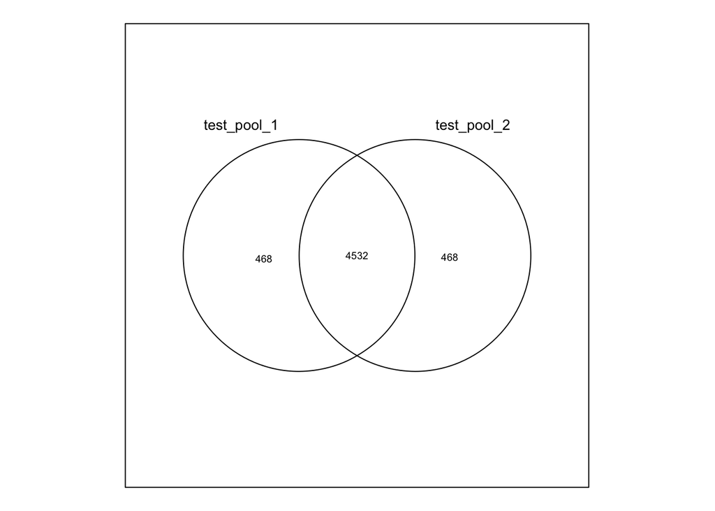

```r
overlap <- calculate.overlap(barcode.list)
venn::venn(barcode.list)
```

Look at overlapping and unique barcode numbers

Common barcodes

```r
common.barcodes <- unlist(overlap["a3"])
length(common.barcodes)
```

```
## [1] 4532
```

unique - PCR1

```r
ol <- starcode.1$V1 %in% common.barcodes
pool1.unique.barcodes <- starcode.1$V1[!ol]
length(pool1.unique.barcodes)
```

```
## [1] 468
```

unique - PCR2

```r
ol <- starcode.2$V1 %in% common.barcodes
pool2.unique.barcodes <- starcode.2$V1[!ol]
length(pool2.unique.barcodes)
```

```
## [1] 468
```

Generate Venn diagram of barcode overlap - Filtered Barcodes

```r
# Venn diagram of barcode overlap - Filtered Barcodes
barcode.list <- list("test_pool_1" = barcodes.starcode.filtered.1$Barcode,
                     "test_pool_2" = barcodes.starcode.filtered.2$Barcode)
venn.diagram(barcode.list, filename = file.path(plot.dir, "test_library_pools_filtered_overlap.png"), imagetype = "png")
```

```
## [1] 1
```

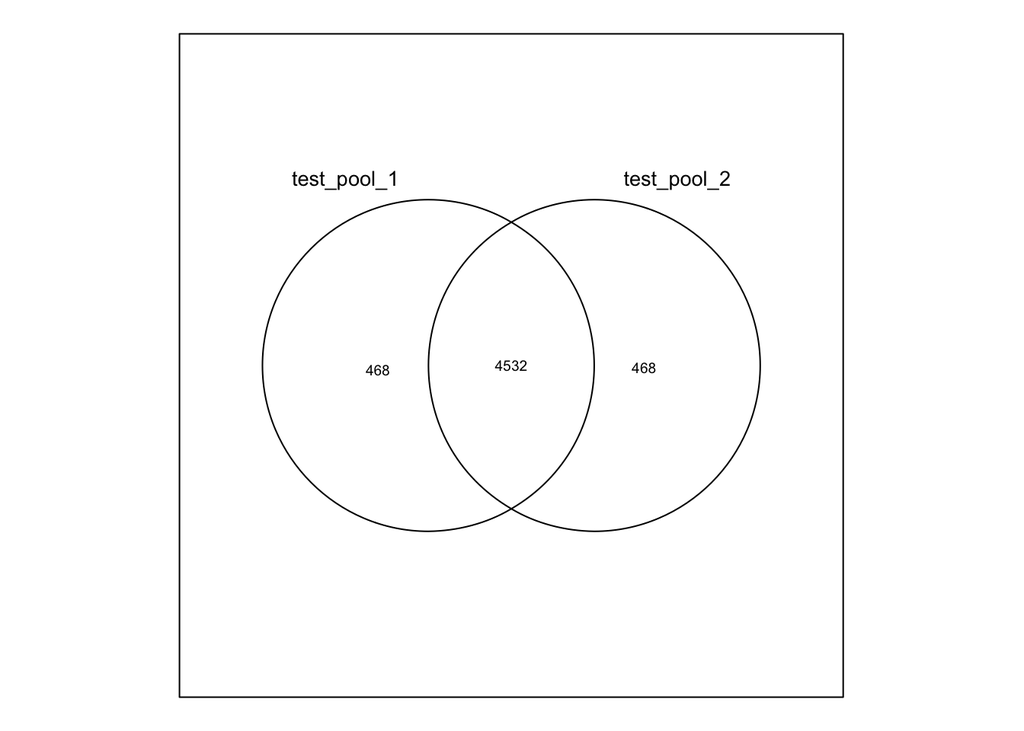

```r
venn::venn(barcode.list)
```

```r
overlap <- calculate.overlap(barcode.list)
str(overlap)
```

```
## List of 3
##  $ a1: chr [1:5000] "TTCTGTTTGTATCAGACACTAACACAGAGTTAGTCTTAGATCCAGCTTCTGTGTGCGTCA" "TCCACTGTCATGCTGAGTGAATGTGGATCAGAGAGGGTCAATCTGTTAGACTGACGCTCT" "ACCAGAAAGAGTGTGATTCAACCTGTAAGAATGTCAGACAGTCTGTATGTGTCTGGCTCT" "TTCTGTGTCTTGGAGTGTCTTGCTCCCACTGTGTGTGTGTTCGTCACACATGGAGAAACT" ...
##  $ a2: chr [1:5000] "GCCACTGTCAACGAGATTCAGCCTGGGTCAAACTGGATGTTGGTCCTTGACACTCGTAGT" "TCCACTGTCATGCTGAGTGAATGTGGATCAGAGAGGGTCAATCTGTTAGACTGACGCTCT" "ATCAGCGACATGCACCAACACACTGTCTCAATGTGCCAGATTGAGCGAGAAGGTGTGTGT" "TTCTGTTTGTATCAGACACTAACACAGAGTTAGTCTTAGATCCAGCTTCTGTGTGCGTCA" ...
##  $ a3: chr [1:4532] "TTCTGTTTGTATCAGACACTAACACAGAGTTAGTCTTAGATCCAGCTTCTGTGTGCGTCA" "TCCACTGTCATGCTGAGTGAATGTGGATCAGAGAGGGTCAATCTGTTAGACTGACGCTCT" "ACCAGAAAGAGTGTGATTCAACCTGTAAGAATGTCAGACAGTCTGTATGTGTCTGGCTCT" "TTCTGTGTCTTGGAGTGTCTTGCTCCCACTGTGTGTGTGTTCGTCACACATGGAGAAACT" ...
```

```r
names(overlap)
```

```
## [1] "a1" "a2" "a3"
```

```r
common.barcodes.filtered <- unlist(overlap["a3"])
length(common.barcodes.filtered)
```

```
## [1] 4532
```

Finally we can generate a set of the common barcodes and their abundances and use this as a reference set for the barcode library. Sequencing depth normalised counts for each barcode should be similar between technical replicates.

```r
# Generate final output table of filtered barcodes
common.barcodes.filtered <- as.data.frame(common.barcodes.filtered)

# inner join TR 1 and TR2
common.barcodes.filtered <- inner_join(common.barcodes.filtered, barcodes.starcode.filtered.1, by = (c("common.barcodes.filtered" = "Barcode")))
common.barcodes.filtered <- inner_join(common.barcodes.filtered, barcodes.starcode.filtered.2, by = (c("common.barcodes.filtered" = "Barcode")))
# calculate CPM for each replicate
common.barcodes.filtered <- common.barcodes.filtered %>%
    mutate(TR1_CPM = Raw_Count.x/sum(Raw_Count.x)*10e6)
common.barcodes.filtered <- common.barcodes.filtered %>%
    mutate(TR2_CPM = Raw_Count.y/sum(Raw_Count.y)*10e6)
head(common.barcodes.filtered)
```

|  | common.barcodes.filtered | Raw_Count.x | Raw_Count.y | TR1_CPM | TR2_CPM |
| --- | --- | --- | --- | --- | --- |
| 1 | TTCTGTTTGTATCAGACACTAACACAGAGTTAGTCTTAGATCCAGCTTCTGTGTGCGTCA | 7058 | 6973 | 5286 | 5110 |
| 2 | TCCACTGTCATGCTGAGTGAATGTGGATCAGAGAGGGTCAATCTGTTAGACTGACGCTCT | 6921 | 7320 | 5184 | 5364 |
| 3 | ACCAGAAAGAGTGTGATTCAACCTGTAAGAATGTCAGACAGTCTGTATGTGTCTGGCTCT | 6883 | 6873 | 5155 | 5037 |
| 4 | TTCTGTGTCTTGGAGTGTCTTGCTCCCACTGTGTGTGTGTTCGTCACACATGGAGAAACT | 6809 | 6385 | 5100 | 4679 |
| 5 | GCCACTGTCAACGAGATTCAGCCTGGGTCAAACTGGATGTTGGTCCTTGACACTCGTAGT | 6748 | 7362 | 5054 | 5395 |
| 6 | AGGTGCGACTATGTGTTTGTTTGTCCATGTCAGTGACTGACCGTCGTTCTTTGTCGAACT | 6535 | 6510 | 4895 | 4771 |

```r
# calculate average CPM
head(common.barcodes.filtered)
```

|  | common.barcodes.filtered | Raw_Count.x | Raw_Count.y | TR1_CPM | TR2_CPM |
| --- | --- | --- | --- | --- | --- |
| 1 | TTCTGTTTGTATCAGACACTAACACAGAGTTAGTCTTAGATCCAGCTTCTGTGTGCGTCA | 7058 | 6973 | 5286 | 5110 |
| 2 | TCCACTGTCATGCTGAGTGAATGTGGATCAGAGAGGGTCAATCTGTTAGACTGACGCTCT | 6921 | 7320 | 5184 | 5364 |
| 3 | ACCAGAAAGAGTGTGATTCAACCTGTAAGAATGTCAGACAGTCTGTATGTGTCTGGCTCT | 6883 | 6873 | 5155 | 5037 |
| 4 | TTCTGTGTCTTGGAGTGTCTTGCTCCCACTGTGTGTGTGTTCGTCACACATGGAGAAACT | 6809 | 6385 | 5100 | 4679 |
| 5 | GCCACTGTCAACGAGATTCAGCCTGGGTCAAACTGGATGTTGGTCCTTGACACTCGTAGT | 6748 | 7362 | 5054 | 5395 |
| 6 | AGGTGCGACTATGTGTTTGTTTGTCCATGTCAGTGACTGACCGTCGTTCTTTGTCGAACT | 6535 | 6510 | 4895 | 4771 |

```r
dim(common.barcodes.filtered)
```

```
## [1] 4532    5
```

```r
common.barcodes.filtered <- common.barcodes.filtered %>% as_tibble() %>% rowwise() %>% mutate(Mean_CPM = mean(c(TR1_CPM, TR2_CPM), na.rm=T))

# calculate difference in CPM
common.barcodes.filtered <- common.barcodes.filtered %>% rowwise() %>% mutate(Diff = TR1_CPM - TR2_CPM)

colnames(common.barcodes.filtered) <- c("Barcode", "Filtered_Count_TR1", "Filtered_Count_TR2", "CPM_TR1", "CPM_TR2", "Mean_CPM", "CPM_Diff")
head(common.barcodes.filtered)
```

| Barcode | Filtered_Count_TR1 | Filtered_Count_TR2 | CPM_TR1 | CPM_TR2 | Mean_CPM | CPM_Diff |
| --- | --- | --- | --- | --- | --- | --- |
| TTCTGTTTGTATCAGACACTAACACAGAGTTAGTCTTAGATCCAGCTTCTGTGTGCGTCA | 7058 | 6973 | 5286 | 5110 | 5198 | 176.1 |
| TCCACTGTCATGCTGAGTGAATGTGGATCAGAGAGGGTCAATCTGTTAGACTGACGCTCT | 6921 | 7320 | 5184 | 5364 | 5274 | -180.8 |
| ACCAGAAAGAGTGTGATTCAACCTGTAAGAATGTCAGACAGTCTGTATGTGTCTGGCTCT | 6883 | 6873 | 5155 | 5037 | 5096 | 118.3 |
| TTCTGTGTCTTGGAGTGTCTTGCTCCCACTGTGTGTGTGTTCGTCACACATGGAGAAACT | 6809 | 6385 | 5100 | 4679 | 4890 | 420.5 |
| GCCACTGTCAACGAGATTCAGCCTGGGTCAAACTGGATGTTGGTCCTTGACACTCGTAGT | 6748 | 7362 | 5054 | 5395 | 5225 | -341.2 |
| AGGTGCGACTATGTGTTTGTTTGTCCATGTCAGTGACTGACCGTCGTTCTTTGTCGAACT | 6535 | 6510 | 4895 | 4771 | 4833 | 123.7 |

Histogram of CPM differences between PCR replicates

```r
min.max <- summary(common.barcodes.filtered$CPM_Diff)
min.max
```

```
##    Min. 1st Qu.  Median    Mean 3rd Qu.    Max.
##  -522.7   -71.0    -0.7     0.0    69.6   507.7
```

```r
pdf(file.path(plot.dir,"test_difference_in_CPMs.pdf"), width = 6, height = 5)
hist(common.barcodes.filtered$CPM_Diff, main = "Distribution of CPM differences between PCR replicates")
dev.off()
```

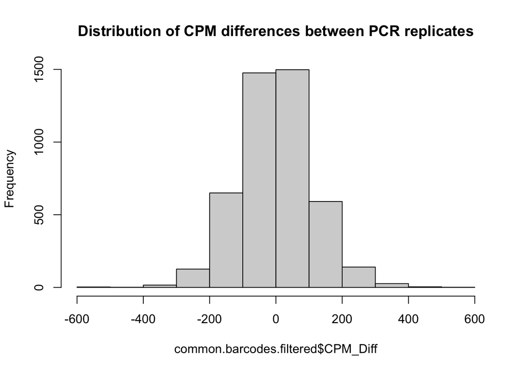

```r
hist(common.barcodes.filtered$CPM_Diff, main = "Distribution of CPM differences between PCR replicates")
```

Scatter plot

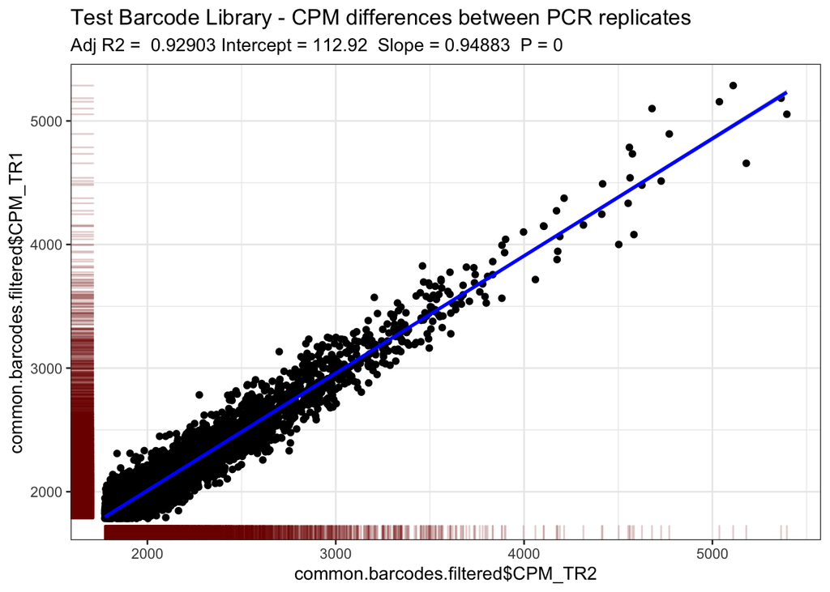

```r
fit <- lm(common.barcodes.filtered$CPM_TR1 ~ common.barcodes.filtered$CPM_TR2)
p <- ggplotRegression(fit, "Test Barcode Library - CPM differences between PCR replicates")
ggsave(file.path(plot.dir,"Test_filtered_barcode_CPMs_scatterplot.pdf"), width = 6, height = 5)
p
```

```r
# filter largest CPM differences

# order based on CPM average
common.barcodes.filtered <- common.barcodes.filtered[order(common.barcodes.filtered$Mean_CPM, decreasing = T),]

# name Barcodes by rank abundance in pool
common.barcodes.filtered <- as.data.frame(common.barcodes.filtered)
rownames(common.barcodes.filtered) <- paste("Test_Barcode_", rownames(common.barcodes.filtered), sep = '')
head(common.barcodes.filtered)
```

|  | Barcode | Filtered_Count_TR1 | Filtered_Count_TR2 | CPM_TR1 | CPM_TR2 | Mean_CPM | CPM_Diff |
| --- | --- | --- | --- | --- | --- | --- | --- |
| Test_Barcode_1 | TCCACTGTCATGCTGAGTGAATGTGGATCAGAGAGGGTCAATCTGTTAGACTGACGCTCT | 6921 | 7320 | 5184 | 5364 | 5274 | -180.8 |
| Test_Barcode_2 | GCCACTGTCAACGAGATTCAGCCTGGGTCAAACTGGATGTTGGTCCTTGACACTCGTAGT | 6748 | 7362 | 5054 | 5395 | 5225 | -341.2 |
| Test_Barcode_3 | TTCTGTTTGTATCAGACACTAACACAGAGTTAGTCTTAGATCCAGCTTCTGTGTGCGTCA | 7058 | 6973 | 5286 | 5110 | 5198 | 176.1 |
| Test_Barcode_4 | ACCAGAAAGAGTGTGATTCAACCTGTAAGAATGTCAGACAGTCTGTATGTGTCTGGCTCT | 6883 | 6873 | 5155 | 5037 | 5096 | 118.3 |
| Test_Barcode_5 | ATCAGCGACATGCACCAACACACTGTCTCAATGTGCCAGATTGAGCGAGAAGGTGTGTGT | 6218 | 7068 | 4657 | 5180 | 4918 | -522.7 |
| Test_Barcode_6 | TTCTGTGTCTTGGAGTGTCTTGCTCCCACTGTGTGTGTGTTCGTCACACATGGAGAAACT | 6809 | 6385 | 5100 | 4679 | 4890 | 420.5 |

```r
# output reference dataset
write.table(common.barcodes.filtered, quote = F, file = file.path(results.dir,"./test_barcode_reference_library.txt"))

# output reference fasta file of barcodes
seqinr::write.fasta(sequences = as.list(common.barcodes.filtered$Barcode), names = rownames(common.barcodes.filtered), file.out = file.path(results.dir,"./test_barcode_reference_library.fasta"))
```